# wb-templates

AI-generated text

Documentation and verification

2026-11-26

## What this collection provides

Copy a reusable scientific template and its declared inputs, tests and license.

- **Modernization** connects bounded scientific capabilities so that models can be verified independently.
- **Plot styles and CSV I/O** help inspect outputs with a reproducible figure style and explicit data columns.
- **Documentation** uses the same Markdown inputs for a detailed report and a short presentation.

Read the detailed guide

## Compare the three observables

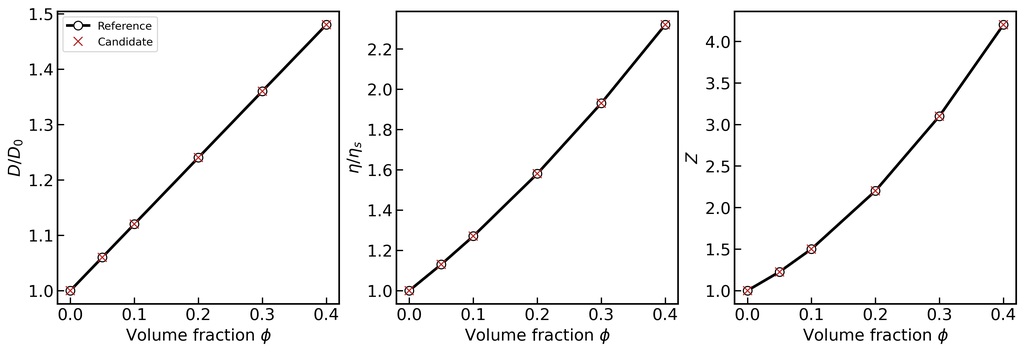

Synthetic concentration sweep. Black open circles show the reference; red crosses show the candidate.

Report and numerical table / CSV

## Review a source-code change

```
-    viscosity = 1.0 + 2.5 * phi + 2.0 * phi ** 2
+    viscosity = 1.0 + phi * (2.5 + 2.0 * phi)
```

The synthetic example compares six concentrations and all three reduced quantities with a declared absolute tolerance of $10^{-14}$.

Full diff and method

## Edit the source

- **Slides:** edit `slides.qmd`. Find the slide by its heading.
- **Report:** edit `report.qmd` for chapter order or edit the relevant Markdown chapter for the text.
- **Figures and data:** edit the input models or `tools/make_example.py` and regenerate the comparison assets.

From the template folder, choose a fresh build destination.

```bash
sh render.sh /tmp/wb-comparison-updated
```

## Author and project information

**Author and Project Director:** Gunwoo Park

Project overview:  
https://github.com/gwpark-git/agentic-workbench-knowledge

wb-templates repository (planned):  
https://github.com/gwpark-git/wb-templates

### AI assistance

OpenAI Codex assisted with drafting and editing the documentation under Gunwoo Park’s direction. The scientific sources and evidence are credited where the results are discussed.

Edit